# Kazakhstan MICS 2024

# What a reader might need to know about the modeling process

## Pipeline

The development of models and variable selection was following the logic below:

1. First, we run a null model to check whether multilevel approach is justified at all
2. Next, we run a model with the most exhaustive list of predictors that are shared accross countries’ datasets, called a “model for pooling”. This model is run through anova to see whether it fits the data significantly better than the null model.
3. After that, we do a little robustness check, running (almost) the same model for pooling through the regular logistic regression rather than multilevel one.
4. Then, we include all variables available for the country (that are of our interest) into a “full” model and check whether it is significantly different in prediction than a model for pooling.
5. Also, we are tracking r^2 and collinearity metrics all way along.
6. As a next step, we remove all non-significant variables from a full model, calling this model “model_sign”, and based on it, conduct some questionable experiments with interactions and random slopes and call it ‘model_extra’
7. Finally, we are actually doing some machine learning-style performance evaluation of all of the models, preserving the formulas, but re-training them on randomly (but within stratas) split data.

## Key takeaways for Kazakhstan

- Sometimes, models failed to converge, but that is not too critical (?)
- Multilevel modeling for Kazakhstan is least justified in comparison to other countries, but still doable.
- Robustness check is passed by a model for pooling - individual-level coefficients remained almost the same
- Full model mostly won in performance (accuracy 0.715, precision 0.728, see further metrics),
- Significant variables were: child’s age in months [+], caregiver’s education [+], number of books in the household [+], inadequate supervision [-], early stimulation [+], child being developmentally on track [+], household wealth index quintile [+], household size [-], total population of the region [-], number of preschool pedagogical workers in the region [+]. Population density was significant in the full model, but stopped being significant in model_sign.
- R-squared is the lowest across all countries within the analysis: highest conditional R^2 reached was 0.134. See a model comparison table

# Loading data

```r
# Indiv-level data
kazakhstan_mics <- get_and_preprocess_mics_data("Kazakhstan")

# Region-level data
region_kz <- read_csv("../data/raw/regional_data_Kazakhstan_2024.csv")
```

# Preprocessing individual level data

## Dimensionality reduction

```r
kazakhstan_mics <- kazakhstan_mics %>%

  # Learning materials
  recode_playthings(books_var = "EC1",
                    playthings_vars = c("EC2A", "EC2B", "EC2C")) %>%

  # Inadequate supervision
  recode_supervision(supervision_vars = c("EC3A", "EC3B")) %>%

  # Child discipline - psychological aggression
  recode_psy_aggression(var1 = "UCD2D", var2 = "UCD2H") %>%

  # Early stimulation and responsive care
  recode_early_stimulation(stimulation_vars = c("EC5A", "EC5B", "EC5C",
                                                "EC5D", "EC5E", "EC5F")) %>%

  # ECDI
  recode_ecdi_and_track(age_col = "CAGE",
                        ec_regular = paste0("EC", 6:23),
                        ec_frequency = "EC24",
                        ec_comparison = "EC25") %>%
  mutate(UB8=if_else(UB8==1, 1,0)) %>%
  mutate(HC10E=if_else(HC10E==1, 1,0)) %>%

  # Caregiver's education
  recode_education_scheme("ED5A", "KZ") %>%

  # Sample one child from household
  sample_one_per_group(group_var = "house_index",
                       seed = 42) %>%

  # Omit rows with missing values for key predictors
  filter_at(vars(ED5A, HL13, HL17), all_vars(!is.na(.)))
```

## Imputation

```r
kazakhstan_mics$UB8[is.na(kazakhstan_mics$UB8)] <- 0
```

# Correlations and associations

```r
results <- pairwise_chi_cramers_parallel(
  kazakhstan_mics[, names(kazakhstan_mics) %in% c("UB2", "ED5A","UB8","HH48", "HH51","HC10E", "HH7", "HH6", "HL13", "HL17", "windex5", "ED4", "playthings_sum", "two_plus_playthings", "supervised_inadequately", "psy_aggression", "early_stimulation", "ecdi_sum", "dev_on_track" )], n_cores = 4, p_threshold = 0.05, use_bonferroni = FALSE)
```

```
## Processing 171 pairs using 4 cores...
## Found 96 significant pairs
```

```r
# Get summary
summary_stats(results)
```

```
##
## === Association Analysis Summary ===
##
## Total variables: 19
## Possible pairs: 171
## Computed pairs: 171
## Significant pairs: 96 (56.1%)
## Adjusted p-value threshold: 5.00e-02
##
## --- Cramer's V Statistics (Significant Associations) ---
## Mean: 0.169
## Median: 0.117
## Min: 0.041
## Max: 1.000
##
## --- Effect Size Distribution ---
## Weak (< 0.1): 76 (39.6%)
## Small (0.1-0.3): 90 (46.9%)
## Medium (0.3-0.5): 18 (9.4%)
## Large (>= 0.5): 8 (4.2%)
```

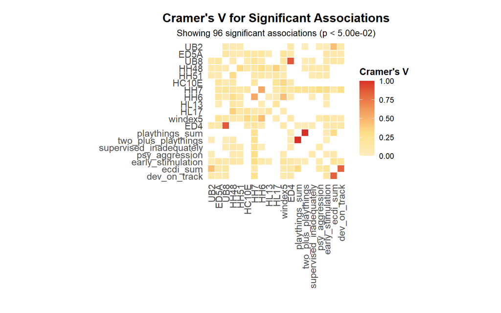

```r
# Create heatmap
plot <- plot_cramers_heatmap(results, text_size_x = 11, text_size_y = 11)
print(plot)
```

```r
# View top associations
top_20 <- get_top_associations(results, n = 20)
print(top_20)
```

```
##               Var1                    Var2  CramersV ChiSquare        PValue
## 91  playthings_sum     two_plus_playthings 1.0000000 2681.0000  0.000000e+00
## 58             UB8                     ED4 0.8779040 2066.2879  0.000000e+00
## 171       ecdi_sum            dev_on_track 0.8388774 1886.6608  0.000000e+00
## 28             HH7                     HH6 0.5485002  806.5853 8.562590e-159
## 53             HH6                 windex5 0.4534742  551.3178 5.306526e-118
## 137            UB2                ecdi_sum 0.4421487  524.1234  4.809836e-99
## 40            HH48                    HL17 0.3635398  354.3241  2.947338e-69
## 51           HC10E                 windex5 0.3376029  305.5690  6.814845e-65
## 149 playthings_sum                ecdi_sum 0.3194797  820.9272 7.488300e-136
## 10            HH48                    HH51 0.3159073 1337.7848 1.185501e-243
## 112            HH7          psy_aggression 0.3104768  258.4373  6.025590e-44
## 127            HH7       early_stimulation 0.3103929  258.2976  6.432148e-44
## 25            HH48                     HH6 0.3023466  245.0795  2.993348e-46
## 160            HH7            dev_on_track 0.2872575  221.2278  1.954982e-36
## 73             HH7          playthings_sum 0.2559663  526.9672  2.693334e-77
## 85             HH7     two_plus_playthings 0.2502092  167.8430  7.505943e-26
## 52             HH7                 windex5 0.2388459  611.7760  1.089870e-84
## 42           HC10E                    HL17 0.2296151  141.3506  1.348552e-32
## 98             HH7 supervised_inadequately 0.2270360  138.1931  4.041585e-20
## 47            ED5A                 windex5 0.2154819  373.4562  1.561741e-72
```

# Combining data for multilevel modeling

```r
# If we decide to grand-center anything
region_kz <- region_kz %>%
  # Log-transform to compress the scale
  mutate(places_in_pre_total = places_in_pre_total/1000,
         popul_total_01012024 = popul_total_01012024/1000000,
         pre_teachers_total_2024 = pre_teachers_total_2024/100)
region_kz <- grand_mean_centering(region_kz, colnames(region_kz)[-c(1:3)])
region_kz <- region_kz %>%
  # Log-transform to compress the scale
  mutate(popul_density_log = log(popul_density),
         total_pre_2024_log = log(total_pre_2024))

kaz_df <- kazakhstan_mics %>%
  mutate(region_mics = as.character(as_factor(HH7))) %>%
  left_join(region_kz,
            by = "region_mics",
            keep = FALSE)
```

# Modeling

## Baseline models

### Null model

```r
# RANDOM INTERCEPT WITH FIXED SLOPES

# Null model (unconditional model) - to calculate ICC
model_null <- glmer(
  UB8 ~ 1 + (1 | region_mics),
  data = kaz_df,
  family = binomial(link = "logit"),
  control = glmerControl(optimizer = "bobyqa", optCtrl = list(maxfun = 100000))
)

# Calculate Intraclass Correlation Coefficient (ICC)
# ICC tells us how much variance is due to clustering
# An ICC > 0.05 or 0.10 or typically justifies using a multilevel model
vpc_null <- performance::icc(model_null)
print(paste("ICC:", round(vpc_null$ICC_adjusted, 3)))
```

```
## [1] "ICC: 0.047"
```

4.7% of the variance in UB8 was attributable to differences between regions (ICC = 0.047), indicating modest clustering. We prefer to conclude that multilevel modeling is justified.

### All individual predictors + universal regional predictors

```r
# Baseline random intercept model
model_for_pooling <- glmer(
  UB8 ~
    # Level 1 predictors (child/household)
    CAGE + # Age in months
    ED5A + # mother's/caregiver's education
    EC1 + #Three or more books
    two_plus_playthings +
    supervised_inadequately +
    psy_aggression +
    early_stimulation +
    dev_on_track +
    HH6 + # Rural/urban
    HH48 + # household size
    HL13 + # Natural mother lives in the household
    HL17 + # Natural father lives in the household
    windex5 +
    HC10E + # Family has a car

    # Level 2 predictors (structure)
    popul_total_01012024 +
    popul_density_log +
    total_pre_2024_log +

    # Random intercept for region
    (1 | region),

  data = kaz_df,
  family = binomial(link = "logit"),
  control = glmerControl(optimizer = "bobyqa", optCtrl = list(maxfun = 100000))
)
# Model summary
summary(model_for_pooling, correlation =TRUE)
```

```
## Generalized linear mixed model fit by maximum likelihood (Laplace
##   Approximation) [glmerMod]
##  Family: binomial  ( logit )
## Formula:
## UB8 ~ CAGE + ED5A + EC1 + two_plus_playthings + supervised_inadequately +
##     psy_aggression + early_stimulation + dev_on_track + HH6 +
##     HH48 + HL13 + HL17 + windex5 + HC10E + popul_total_01012024 +
##     popul_density_log + total_pre_2024_log + (1 | region)
##    Data: kaz_df
## Control: glmerControl(optimizer = "bobyqa", optCtrl = list(maxfun = 1e+05))
##
##       AIC       BIC    logLik -2*log(L)  df.resid
##    3168.3    3280.3   -1565.2    3130.3      2662
##
## Scaled residuals:
##     Min      1Q  Median      3Q     Max
## -3.0265 -0.9846  0.4944  0.6749  1.7911
##
## Random effects:
##  Groups Name        Variance Std.Dev.
##  region (Intercept) 0.1221   0.3495
## Number of obs: 2681, groups:  region, 20
##
## Fixed effects:
##                          Estimate Std. Error z value Pr(>|z|)
## (Intercept)             -4.106425   1.734746  -2.367  0.01793 *
## CAGE                     0.027608   0.006562   4.208 2.58e-05 ***
## ED5A                     0.250739   0.060973   4.112 3.92e-05 ***
## EC1                      0.263676   0.101864   2.588  0.00964 **
## two_plus_playthings     -0.228189   0.121915  -1.872  0.06125 .
## supervised_inadequately -0.344802   0.145666  -2.367  0.01793 *
## psy_aggression           0.140222   0.099788   1.405  0.15996
## early_stimulation        0.235302   0.109818   2.143  0.03214 *
## dev_on_track             0.349705   0.107609   3.250  0.00115 **
## HH6                      0.071175   0.112749   0.631  0.52786
## HH48                    -0.054386   0.028225  -1.927  0.05399 .
## HL13                     0.694751   0.542653   1.280  0.20044
## HL17                     0.143512   0.189677   0.757  0.44928
## windex5                  0.167116   0.040536   4.123 3.75e-05 ***
## HC10E                    0.196638   0.106037   1.854  0.06368 .
```

[output cut: 31 more lines]

```
## psy_aggrssn
## erly_stmltn
## dev_on_trck
## HH6
## HH48        -0.180
## HL13        -0.038  0.018
## HL17         0.039  0.145 -0.178
## windex5      0.343 -0.030  0.012  0.037
## HC10E       -0.118 -0.095 -0.039  0.184 -0.315
## p__01012024 -0.039 -0.018  0.004 -0.012 -0.033 -0.031
## ppl_dnsty_l  0.164  0.017 -0.003  0.005 -0.046  0.016 -0.575
## ttl_p_2024_ -0.049  0.005 -0.003  0.007  0.068  0.008 -0.769  0.180
## optimizer (bobyqa) convergence code: 0 (OK)
## Model failed to converge with max|grad| = 0.00604954 (tol = 0.002, component 1)
##   See ?lme4::convergence and ?lme4::troubleshooting.
```

```r
or_model <- model_for_pooling
ame_model <- avg_slopes(model_for_pooling, type = "response")
modelsummary(
  list(
    "Odds Ratios" = or_model,
    "Marginal Effects" = ame_model
  ),
  exponentiate = c(TRUE, FALSE),
  statistic = "conf.int",
  stars = TRUE,
  output = "gt"
)
```

|  | Odds Ratios | Marginal Effects |
| --- | --- | --- |
| (Intercept) | 0.016* |  |
|  | [0.001, 0.493] |  |
| CAGE | 1.028*** | 0.005*** |
|  | [1.015, 1.041] | [0.003, 0.008] |
| ED5A | 1.285*** | 0.050*** |
|  | [1.140, 1.448] | [0.026, 0.073] |
| EC1 | 1.302** | 0.052* |
|  | [1.066, 1.589] | [0.012, 0.092] |
| two_plus_playthings | 0.796+ | -0.044+ |
|  | [0.627, 1.011] | [-0.089, 0.001] |
| supervised_inadequately | 0.708* | -0.071* |
|  | [0.532, 0.942] | [-0.132, -0.010] |
| psy_aggression | 1.151 | 0.027 |
|  | [0.946, 1.399] | [-0.010, 0.065] |
| early_stimulation | 1.265* | 0.048* |
|  | [1.020, 1.569] | [0.003, 0.092] |
| dev_on_track | 1.419** | 0.072** |
|  | [1.149, 1.752] | [0.027, 0.116] |
| HH6 | 1.074 | 0.014 |
|  | [0.861, 1.339] | [-0.030, 0.058] |
| HH48 | 0.947+ | -0.011+ |
|  | [0.896, 1.001] | [-0.022, 0.000] |
| HL13 | 2.003 | 0.137 |
|  | [0.692, 5.803] | [-0.073, 0.347] |
| HL17 | 1.154 | 0.028 |
|  | [0.796, 1.674] | [-0.045, 0.102] |
| windex5 | 1.182*** | 0.033*** |
|  | [1.092, 1.280] | [0.017, 0.049] |
| HC10E | 1.217+ | 0.040+ |
|  | [0.989, 1.499] | [-0.003, 0.082] |
| popul_total_01012024 | 0.587 | -0.105 |
|  | [0.273, 1.263] | [-0.256, 0.046] |
| popul_density_log | 1.051 | 0.010 |
|  | [0.934, 1.182] | [-0.013, 0.033] |
| total_pre_2024_log | 1.329 | 0.056 |
|  | [0.744, 2.375] | [-0.058, 0.171] |
| SD (Intercept region) | 0.349 |  |
| Num.Obs. | 2681 | 2681 |
| R2 Marg. | 0.102 | 0.102 |
| R2 Cond. | 0.134 | 0.134 |
| AIC | 3168.3 | 3168.3 |
| BIC | 3280.3 | 3280.3 |
| ICC | 0.0 | 0.0 |
| RMSE | 0.44 | 0.44 |

+ p < 0.1, * p < 0.05, ** p < 0.01, *** p < 0.001

```r
anova(model_null, model_for_pooling)
```

```
## Data: kaz_df
## Models:
## model_null: UB8 ~ 1 + (1 | region_mics)
## model_for_pooling: UB8 ~ CAGE + ED5A + EC1 + two_plus_playthings + supervised_inadequately + psy_aggression + early_stimulation + dev_on_track + HH6 + HH48 + HL13 + HL17 + windex5 + HC10E + popul_total_01012024 + popul_density_log + total_pre_2024_log + (1 | region)
##                   npar    AIC    BIC  logLik -2*log(L) Chisq Df Pr(>Chisq)
## model_null           2 3307.0 3318.8 -1651.5    3303.0
## model_for_pooling   19 3168.3 3280.3 -1565.2    3130.3 172.7 17  < 2.2e-16 ***
## ---
## Signif. codes:  0 '***' 0.001 '**' 0.01 '*' 0.05 '.' 0.1 ' ' 1
```

```r
check_collinearity(model_for_pooling)
```

```
## # Check for Multicollinearity
##
## Low Correlation
##
##                     Term  VIF   VIF 95% CI adj. VIF Tolerance Tolerance 95% CI
##                     CAGE 1.01 [1.00, 1.22]     1.01      0.99     [0.82, 1.00]
##                     ED5A 1.14 [1.10, 1.20]     1.07      0.88     [0.84, 0.91]
##                      EC1 1.16 [1.11, 1.21]     1.08      0.87     [0.82, 0.90]
##      two_plus_playthings 1.01 [1.00, 1.30]     1.01      0.99     [0.77, 1.00]
##  supervised_inadequately 1.02 [1.00, 1.16]     1.01      0.98     [0.86, 1.00]
##           psy_aggression 1.03 [1.01, 1.11]     1.02      0.97     [0.90, 0.99]
##        early_stimulation 1.13 [1.09, 1.19]     1.06      0.88     [0.84, 0.91]
##             dev_on_track 1.04 [1.02, 1.11]     1.02      0.96     [0.90, 0.98]
##                      HH6 1.28 [1.23, 1.34]     1.13      0.78     [0.74, 0.82]
##                     HH48 1.12 [1.08, 1.17]     1.06      0.90     [0.85, 0.93]
##                     HL13 1.04 [1.02, 1.11]     1.02      0.96     [0.90, 0.98]
##                     HL17 1.12 [1.08, 1.18]     1.06      0.89     [0.85, 0.92]
##                  windex5 1.49 [1.42, 1.57]     1.22      0.67     [0.64, 0.71]
##                    HC10E 1.23 [1.19, 1.30]     1.11      0.81     [0.77, 0.84]
##     popul_total_01012024 4.77 [4.46, 5.11]     2.18      0.21     [0.20, 0.22]
##        popul_density_log 2.08 [1.97, 2.21]     1.44      0.48     [0.45, 0.51]
##       total_pre_2024_log 3.31 [3.10, 3.53]     1.82      0.30     [0.28, 0.32]
```

```r
r2(model_for_pooling)
```

```
## # R2 for Mixed Models
##
##   Conditional R2: 0.134
##      Marginal R2: 0.102
```

```r
r2(model_null)
```

```
## # R2 for Mixed Models
##
##   Conditional R2: 0.047
##      Marginal R2: 0.000
```

```r
# Robustness check
model_fe_region <- glm(
  UB8 ~ CAGE + ED5A + EC1 + two_plus_playthings +
    supervised_inadequately + psy_aggression +
    early_stimulation + dev_on_track +
    HH6 + HH48 + HL13 + HL17 + windex5 + HC10E + # Family has a car
    popul_total_01012024 + popul_density_log +
    total_pre_2024_log +
    factor(region),
  data = kaz_df,
  family = binomial
)

modelsummary(
  list(
    "Multilevel model" = model_for_pooling,
    "Region Fixed Effects Model" = model_fe_region
  ),
  exponentiate = TRUE
)
```

```
## Model matrix is rank deficient. Parameters `factor(region)Кyzylorda,
##   factor(region)Коstanay, factor(region)Мangystau` were not estimable.
```

|  | Multilevel model | Region Fixed Effects Model |
| --- | --- | --- |
| (Intercept) | 0.016 | 5.893348e+03 |
|  | (0.029) | (9.814811e+04) |
| CAGE | 1.028 | 1.028000e+00 |
|  | (0.007) | (7.000000e-03) |
| ED5A | 1.285 | 1.282000e+00 |
|  | (0.078) | (7.900000e-02) |
| EC1 | 1.302 | 1.293000e+00 |
|  | (0.133) | (1.340000e-01) |
| two_plus_playthings | 0.796 | 8.090000e-01 |
|  | (0.097) | (1.000000e-01) |
| supervised_inadequately | 0.708 | 7.080000e-01 |
|  | (0.103) | (1.040000e-01) |
| psy_aggression | 1.151 | 1.174000e+00 |
|  | (0.115) | (1.190000e-01) |
| early_stimulation | 1.265 | 1.261000e+00 |
|  | (0.139) | (1.400000e-01) |
| dev_on_track | 1.419 | 1.401000e+00 |
|  | (0.153) | (1.530000e-01) |
| HH6 | 1.074 | 1.084000e+00 |
|  | (0.121) | (1.240000e-01) |
| HH48 | 0.947 | 9.410000e-01 |
|  | (0.027) | (2.700000e-02) |
| HL13 | 2.003 | 2.052000e+00 |
|  | (1.087) | (1.122000e+00) |
| HL17 | 1.154 | 1.174000e+00 |
|  | (0.219) | (2.240000e-01) |
| windex5 | 1.182 | 1.196000e+00 |
|  | (0.048) | (4.900000e-02) |
| HC10E | 1.217 | 1.222000e+00 |
|  | (0.129) | (1.310000e-01) |
| popul_total_01012024 | 0.587 | 1.644078e+05 |
|  | (0.229) | (1.696401e+06) |
| popul_density_log | 1.051 | 7.000000e-03 |
|  | (0.063) | (2.900000e-02) |
| total_pre_2024_log | 1.329 | 1.110000e-01 |
|  | (0.394) | (3.370000e-01) |
| factor(region)Akmola |  | 6.744000e+00 |
|  |  | (1.246200e+01) |
| factor(region)Almaty city |  | 2.723989e+07 |
|  |  | (4.481705e+08) |
| factor(region)Astana city |  | 9.237712e+09 |
|  |  | (1.891552e+11) |
| factor(region)Batys Kazakhstan |  | 4.549000e+00 |
|  |  | (8.447000e+00) |
| factor(region)Pavlodar |  | 8.593000e+00 |
|  |  | (1.198100e+01) |
| factor(region)Shygys Kazakhstan |  | 3.110800e+01 |
|  |  | (7.892400e+01) |
| factor(region)Shymkent city |  | 1.322858e+10 |
|  |  | (2.675503e+11) |
| factor(region)Soltustik Кazakhstan |  | 4.307300e+01 |
|  |  | (1.567300e+02) |
| factor(region)Turkistan |  | 1.000000e-03 |
|  |  | (6.000000e-03) |
| factor(region)Ulytau |  | 2.400000e-02 |
|  |  | (1.050000e-01) |
| factor(region)Zhambyl |  | 3.860000e-01 |
|  |  | (3.630000e-01) |
| factor(region)Zhetisu |  | 8.499000e+00 |
|  |  | (1.652700e+01) |
| factor(region)Аktobе |  | 2.800000e-02 |
|  |  | (5.600000e-02) |
| factor(region)Аlmaty |  | 1.690000e-01 |
|  |  | (1.880000e-01) |
| factor(region)Аtyrau |  | 6.677000e+00 |
|  |  | (1.119400e+01) |
| factor(region)Кaragandy |  | 1.600000e-02 |
|  |  | (5.500000e-02) |
| SD (Intercept region) | 0.349 |  |
| Num.Obs. | 2681 | 2681 |
| R2 Marg. | 0.102 |  |
| R2 Cond. | 0.134 |  |
| AIC | 3168.3 | 3150.4 |
| BIC | 3280.3 | 3350.8 |
| ICC | 0.0 |  |
| Log.Lik. |  | -1541.202 |
| RMSE | 0.44 | 0.44 |

### All available country-specific variables, fixed slopes

```r
model_full <- glmer(
    UB8 ~
    # Level 1 predictors (child/household)
    CAGE + # Age in months
    ED5A + # mother's/caregiver's education
    EC1 + #Three or more books
    two_plus_playthings +
    supervised_inadequately +
    psy_aggression +
    early_stimulation +
    dev_on_track +
    HH6 + # Rural/urban
    HH48 + # household size
    HL13 + # Natural mother lives in the household
    HL17 + # Natural father lives in the household
    windex5 +
    HC10E + # Family has a car

    # Level 2 predictors (structure)
    popul_total_01012024 +
    popul_density_log +
    total_pre_2024_log +
    pre_teachers_total_2024_c +
    child_per_100_places_c +
    places_in_pre_total_c +
    private_pre_share_c +
    labor_force_part_men_2024_c +
    labor_force_part_women_2024_c +

    # Random intercept for region
    (1 | region),

  data = kaz_df,
  family = binomial(link = "logit"),
  control = glmerControl(optimizer = "bobyqa", optCtrl = list(maxfun = 100000))
)

summary(model_full, correlation = TRUE)
```

```
## Generalized linear mixed model fit by maximum likelihood (Laplace
##   Approximation) [glmerMod]
##  Family: binomial  ( logit )
## Formula:
## UB8 ~ CAGE + ED5A + EC1 + two_plus_playthings + supervised_inadequately +
##     psy_aggression + early_stimulation + dev_on_track + HH6 +
##     HH48 + HL13 + HL17 + windex5 + HC10E + popul_total_01012024 +
##     popul_density_log + total_pre_2024_log + pre_teachers_total_2024_c +
##     child_per_100_places_c + places_in_pre_total_c + private_pre_share_c +
##     labor_force_part_men_2024_c + labor_force_part_women_2024_c +
##     (1 | region)
##    Data: kaz_df
## Control: glmerControl(optimizer = "bobyqa", optCtrl = list(maxfun = 1e+05))
##
##       AIC       BIC    logLik -2*log(L)  df.resid
##    3169.2    3316.5   -1559.6    3119.2      2656
##
## Scaled residuals:
##     Min      1Q  Median      3Q     Max
## -3.1006 -0.9869  0.4956  0.6746  1.8427
##
## Random effects:
##  Groups Name        Variance Std.Dev.
##  region (Intercept) 0.04243  0.206
## Number of obs: 2681, groups:  region, 20
##
## Fixed effects:
##                                 Estimate Std. Error z value Pr(>|z|)
## (Intercept)                   -2.6742118  1.8509490  -1.445  0.14852
## CAGE                           0.0277085  0.0065648   4.221 2.43e-05 ***
## ED5A                           0.2521799  0.0610530   4.131 3.62e-05 ***
## EC1                            0.2751549  0.1023555   2.688  0.00718 **
## two_plus_playthings           -0.2277814  0.1218511  -1.869  0.06158 .
## supervised_inadequately       -0.3496472  0.1455617  -2.402  0.01630 *
## psy_aggression                 0.1199709  0.1000048   1.200  0.23027
## early_stimulation              0.2160622  0.1096357   1.971  0.04875 *
## dev_on_track                   0.3382980  0.1072368   3.155  0.00161 **
## HH6                            0.0860637  0.1126389   0.764  0.44483
## HH48                          -0.0542248  0.0284677  -1.905  0.05681 .
## HL13                           0.6884274  0.5429101   1.268  0.20479
```

[output cut: 97 more lines]

```
## HH6
## HH48
## HL13
## HL17
## windex5
## HC10E
## p__01012024
## ppl_dnsty_l
## ttl_p_2024_
## pr_t__2024_
## chld__100__
## plcs_n_pr__
## prvt_pr_sh_
## lbr_frc_prt_m_2024_
## lbr_frc_prt_w_2024_ -0.888
```

```r
or_model_full <- model_full
ame_model_full <- avg_slopes(model_full, type = "response")
modelsummary(
  list("Odds Ratios" = or_model_full, "Marginal Effects" = ame_model_full),
  exponentiate = c(TRUE, FALSE),
  statistic = "conf.int",
  stars = TRUE,
  output = "gt"
)
```

|  | Odds Ratios | Marginal Effects |
| --- | --- | --- |
| (Intercept) | 0.069 |  |
|  | [0.002, 2.595] |  |
| CAGE | 1.028*** | 0.005*** |
|  | [1.015, 1.041] | [0.003, 0.008] |
| ED5A | 1.287*** | 0.050*** |
|  | [1.142, 1.450] | [0.026, 0.073] |
| EC1 | 1.317** | 0.055** |
|  | [1.077, 1.609] | [0.015, 0.095] |
| two_plus_playthings | 0.796+ | -0.044+ |
|  | [0.627, 1.011] | [-0.089, 0.001] |
| supervised_inadequately | 0.705* | -0.072* |
|  | [0.530, 0.938] | [-0.133, -0.011] |
| psy_aggression | 1.127 | 0.023 |
|  | [0.927, 1.372] | [-0.015, 0.062] |
| early_stimulation | 1.241* | 0.044+ |
|  | [1.001, 1.539] | [-0.001, 0.088] |
| dev_on_track | 1.403** | 0.069** |
|  | [1.137, 1.731] | [0.025, 0.114] |
| HH6 | 1.090 | 0.017 |
|  | [0.874, 1.359] | [-0.027, 0.061] |
| HH48 | 0.947+ | -0.011+ |
|  | [0.896, 1.002] | [-0.022, 0.000] |
| HL13 | 1.991 | 0.136 |
|  | [0.687, 5.769] | [-0.074, 0.346] |
| HL17 | 1.147 | 0.027 |
|  | [0.791, 1.664] | [-0.046, 0.101] |
| windex5 | 1.182*** | 0.033*** |
|  | [1.091, 1.280] | [0.017, 0.049] |
| HC10E | 1.218+ | 0.040+ |
|  | [0.989, 1.500] | [-0.003, 0.082] |
| popul_total_01012024 | 0.240* | -0.282* |
|  | [0.072, 0.802] | [-0.519, -0.045] |
| popul_density_log | 1.206* | 0.037* |
|  | [1.026, 1.417] | [0.005, 0.069] |
| total_pre_2024_log | 1.154 | 0.028 |
|  | [0.651, 2.044] | [-0.085, 0.141] |
| pre_teachers_total_2024_c | 1.048** | 0.009** |
|  | [1.018, 1.078] | [0.004, 0.015] |
| child_per_100_places_c | 1.007 | 0.001 |
|  | [0.975, 1.040] | [-0.005, 0.008] |
| places_in_pre_total_c | 0.981* | -0.004* |
|  | [0.963, 1.000] | [-0.007, -0.000] |
| private_pre_share_c | 0.993 | -0.001 |
|  | [0.983, 1.004] | [-0.003, 0.001] |
| labor_force_part_men_2024_c | 1.000 | -0.000 |
|  | [0.931, 1.073] | [-0.014, 0.014] |
| labor_force_part_women_2024_c | 0.981 | -0.004 |
|  | [0.918, 1.049] | [-0.017, 0.009] |
| SD (Intercept region) | 0.206 |  |
| Num.Obs. | 2681 | 2681 |
| R2 Marg. | 0.117 | 0.117 |
| R2 Cond. | 0.128 | 0.128 |
| AIC | 3169.2 | 3169.2 |
| BIC | 3316.5 | 3316.5 |
| ICC | 0.0 | 0.0 |
| RMSE | 0.44 | 0.44 |

+ p < 0.1, * p < 0.05, ** p < 0.01, *** p < 0.001

```r
anova(model_for_pooling, model_full)
```

```
## Data: kaz_df
## Models:
## model_for_pooling: UB8 ~ CAGE + ED5A + EC1 + two_plus_playthings + supervised_inadequately + psy_aggression + early_stimulation + dev_on_track + HH6 + HH48 + HL13 + HL17 + windex5 + HC10E + popul_total_01012024 + popul_density_log + total_pre_2024_log + (1 | region)
## model_full: UB8 ~ CAGE + ED5A + EC1 + two_plus_playthings + supervised_inadequately + psy_aggression + early_stimulation + dev_on_track + HH6 + HH48 + HL13 + HL17 + windex5 + HC10E + popul_total_01012024 + popul_density_log + total_pre_2024_log + pre_teachers_total_2024_c + child_per_100_places_c…
##                   npar    AIC    BIC  logLik -2*log(L) Chisq Df Pr(>Chisq)
## model_for_pooling   19 3168.3 3280.3 -1565.2    3130.3
## model_full          25 3169.2 3316.5 -1559.6    3119.2 11.13  6    0.08444 .
## ---
## Signif. codes:  0 '***' 0.001 '**' 0.01 '*' 0.05 '.' 0.1 ' ' 1
```

```r
check_collinearity(model_full)
```

```
## # Check for Multicollinearity
##
## Low Correlation
##
##                     Term  VIF     VIF 95% CI adj. VIF Tolerance
##                     CAGE 1.02 [ 1.00,  1.17]     1.01      0.98
##                     ED5A 1.15 [ 1.11,  1.21]     1.07      0.87
##                      EC1 1.23 [ 1.18,  1.29]     1.11      0.82
##      two_plus_playthings 1.02 [ 1.00,  1.14]     1.01      0.98
##  supervised_inadequately 1.03 [ 1.01,  1.11]     1.01      0.97
##           psy_aggression 1.05 [ 1.02,  1.11]     1.02      0.95
##        early_stimulation 1.15 [ 1.11,  1.21]     1.07      0.87
##             dev_on_track 1.06 [ 1.03,  1.12]     1.03      0.95
##                      HH6 1.38 [ 1.32,  1.45]     1.18      0.72
##                     HH48 1.18 [ 1.14,  1.24]     1.09      0.85
##                     HL13 1.04 [ 1.02,  1.11]     1.02      0.96
##                     HL17 1.13 [ 1.09,  1.18]     1.06      0.89
##                  windex5 1.57 [ 1.49,  1.65]     1.25      0.64
##                    HC10E 1.25 [ 1.20,  1.31]     1.12      0.80
##   child_per_100_places_c 1.60 [ 1.52,  1.69]     1.26      0.63
##  Tolerance 95% CI
##      [0.85, 1.00]
##      [0.83, 0.90]
##      [0.78, 0.85]
##      [0.88, 1.00]
##      [0.90, 0.99]
##      [0.90, 0.98]
##      [0.83, 0.90]
##      [0.89, 0.97]
##      [0.69, 0.76]
##      [0.81, 0.88]
##      [0.90, 0.98]
##      [0.85, 0.92]
##      [0.61, 0.67]
##      [0.76, 0.83]
##      [0.59, 0.66]
##
## Moderate Correlation
##
##                           Term  VIF     VIF 95% CI adj. VIF Tolerance
##              popul_density_log 7.64 [ 7.12,  8.19]     2.76      0.13
##             total_pre_2024_log 6.69 [ 6.25,  7.18]     2.59      0.15
##            private_pre_share_c 5.38 [ 5.03,  5.76]     2.32      0.19
##    labor_force_part_men_2024_c 7.04 [ 6.57,  7.55]     2.65      0.14
##  labor_force_part_women_2024_c 6.23 [ 5.82,  6.68]     2.50      0.16
##  Tolerance 95% CI
##      [0.12, 0.14]
##      [0.14, 0.16]
##      [0.17, 0.20]
##      [0.13, 0.15]
##      [0.15, 0.17]
##
## High Correlation
##
##                       Term   VIF     VIF 95% CI adj. VIF Tolerance
##       popul_total_01012024 24.18 [22.47, 26.02]     4.92      0.04
##  pre_teachers_total_2024_c 38.09 [35.37, 41.01]     6.17      0.03
##      places_in_pre_total_c 34.13 [31.70, 36.75]     5.84      0.03
##  Tolerance 95% CI
##      [0.04, 0.04]
##      [0.02, 0.03]
##      [0.03, 0.03]
```

```r
r2(model_full)
```

```
## # R2 for Mixed Models
##
##   Conditional R2: 0.128
##      Marginal R2: 0.117
```

## Reduced models

```r
model_sign <- glmer(
    UB8 ~
    # Level 1 predictors (child/household)
    CAGE + # Age in months
    ED5A + # mother's/caregiver's education
    EC1 + #Three or more books
    supervised_inadequately +
    early_stimulation +
    dev_on_track +
    windex5 +
    HH48+

    # Level 2 predictors (structure)
    popul_total_01012024 +
    popul_density_log +
    pre_teachers_total_2024_c +

    # Random intercept for region
    (1 | region),
  data = kaz_df,
  family = binomial(link = "logit"),
  control = glmerControl(optimizer = "bobyqa", optCtrl = list(maxfun = 100000))
)

summary(model_sign, correlation = TRUE)
```

```
## Generalized linear mixed model fit by maximum likelihood (Laplace
##   Approximation) [glmerMod]
##  Family: binomial  ( logit )
## Formula:
## UB8 ~ CAGE + ED5A + EC1 + supervised_inadequately + early_stimulation +
##     dev_on_track + windex5 + HH48 + popul_total_01012024 + popul_density_log +
##     pre_teachers_total_2024_c + (1 | region)
##    Data: kaz_df
## Control: glmerControl(optimizer = "bobyqa", optCtrl = list(maxfun = 1e+05))
##
##       AIC       BIC    logLik -2*log(L)  df.resid
##    3165.9    3242.5   -1569.9    3139.9      2668
##
## Scaled residuals:
##     Min      1Q  Median      3Q     Max
## -2.9252 -1.0077  0.5022  0.6756  1.7437
##
## Random effects:
##  Groups Name        Variance Std.Dev.
##  region (Intercept) 0.09513  0.3084
## Number of obs: 2681, groups:  region, 20
##
## Fixed effects:
##                            Estimate Std. Error z value Pr(>|z|)
## (Intercept)               -0.889315   0.615612  -1.445 0.148569
## CAGE                       0.028751   0.006540   4.396 1.10e-05 ***
## ED5A                       0.253374   0.060457   4.191 2.78e-05 ***
## EC1                        0.265032   0.101490   2.611 0.009017 **
## supervised_inadequately   -0.344574   0.144474  -2.385 0.017078 *
## early_stimulation          0.218214   0.108969   2.003 0.045227 *
## dev_on_track               0.356405   0.106958   3.332 0.000862 ***
## windex5                    0.179836   0.036030   4.991 6.00e-07 ***
## HH48                      -0.053907   0.027054  -1.993 0.046306 *
## popul_total_01012024      -1.253700   0.581548  -2.156 0.031099 *
## popul_density_log          0.099589   0.065134   1.529 0.126264
## pre_teachers_total_2024_c  0.018286   0.009145   2.000 0.045536 *
## ---
## Signif. codes:  0 '***' 0.001 '**' 0.01 '*' 0.05 '.' 0.1 ' ' 1
##
## Correlation of Fixed Effects:
```

[output cut: 9 more lines]

```
## p__01012024 -0.761 -0.001  0.030 -0.083  0.024  0.001  0.023 -0.059  0.103
## ppl_dnsty_l  0.455  0.003 -0.024  0.007  0.010  0.027  0.005 -0.058 -0.029
## pr_t__2024_  0.732  0.005 -0.039  0.106 -0.028  0.000 -0.019  0.095 -0.137
##             p__010 ppl_d_
## CAGE
## ED5A
## EC1
## sprvsd_ndqt
## erly_stmltn
## dev_on_trck
## windex5
## HH48
## p__01012024
## ppl_dnsty_l -0.749
## pr_t__2024_ -0.923  0.577
```

```r
or_model_sign <- model_sign
ame_model_sign <- avg_slopes(model_sign, type = "response")
modelsummary(
  list("Odds Ratios" = or_model_sign, "Marginal Effects" = ame_model_sign),
  exponentiate = c(TRUE, FALSE),
  statistic = "conf.int",
  stars = TRUE,
  output = "gt"
)
```

|  | Odds Ratios | Marginal Effects |
| --- | --- | --- |
| (Intercept) | 0.411 |  |
|  | [0.123, 1.373] |  |
| CAGE | 1.029*** | 0.006*** |
|  | [1.016, 1.042] | [0.003, 0.008] |
| ED5A | 1.288*** | 0.050*** |
|  | [1.144, 1.450] | [0.027, 0.074] |
| EC1 | 1.303** | 0.053** |
|  | [1.068, 1.590] | [0.013, 0.093] |
| supervised_inadequately | 0.709* | -0.071* |
|  | [0.534, 0.940] | [-0.132, -0.011] |
| early_stimulation | 1.244* | 0.044+ |
|  | [1.005, 1.540] | [-0.000, 0.089] |
| dev_on_track | 1.428*** | 0.074** |
|  | [1.158, 1.761] | [0.029, 0.118] |
| windex5 | 1.197*** | 0.036*** |
|  | [1.115, 1.285] | [0.022, 0.050] |
| HH48 | 0.948* | -0.011* |
|  | [0.899, 0.999] | [-0.021, -0.000] |
| popul_total_01012024 | 0.285* | -0.249* |
|  | [0.091, 0.892] | [-0.473, -0.025] |
| popul_density_log | 1.105 | 0.020 |
|  | [0.972, 1.255] | [-0.005, 0.045] |
| pre_teachers_total_2024_c | 1.018* | 0.004* |
|  | [1.000, 1.037] | [0.000, 0.007] |
| SD (Intercept region) | 0.308 |  |
| Num.Obs. | 2681 | 2681 |
| R2 Marg. | 0.096 | 0.096 |
| R2 Cond. | 0.121 | 0.121 |
| AIC | 3165.9 | 3165.9 |
| BIC | 3242.5 | 3242.5 |
| ICC | 0.0 | 0.0 |
| RMSE | 0.44 | 0.44 |

+ p < 0.1, * p < 0.05, ** p < 0.01, *** p < 0.001

```r
anova(model_full, model_sign)
```

```
## Data: kaz_df
## Models:
## model_sign: UB8 ~ CAGE + ED5A + EC1 + supervised_inadequately + early_stimulation + dev_on_track + windex5 + HH48 + popul_total_01012024 + popul_density_log + pre_teachers_total_2024_c + (1 | region)
## model_full: UB8 ~ CAGE + ED5A + EC1 + two_plus_playthings + supervised_inadequately + psy_aggression + early_stimulation + dev_on_track + HH6 + HH48 + HL13 + HL17 + windex5 + HC10E + popul_total_01012024 + popul_density_log + total_pre_2024_log + pre_teachers_total_2024_c + child_per_100_places_c…
##            npar    AIC    BIC  logLik -2*log(L)  Chisq Df Pr(>Chisq)
## model_sign   13 3165.9 3242.5 -1569.9    3139.9
## model_full   25 3169.2 3316.5 -1559.6    3119.2 20.688 12    0.05515 .
## ---
## Signif. codes:  0 '***' 0.001 '**' 0.01 '*' 0.05 '.' 0.1 ' ' 1
```

```r
check_collinearity(model_sign)
```

```
## # Check for Multicollinearity
##
## Low Correlation
##
##                     Term  VIF     VIF 95% CI adj. VIF Tolerance
##                     CAGE 1.01 [ 1.00,  1.55]     1.00      0.99
##                     ED5A 1.13 [ 1.09,  1.18]     1.06      0.89
##                      EC1 1.16 [ 1.12,  1.22]     1.08      0.86
##  supervised_inadequately 1.01 [ 1.00,  2.18]     1.00      0.99
##        early_stimulation 1.13 [ 1.09,  1.18]     1.06      0.89
##             dev_on_track 1.04 [ 1.01,  1.11]     1.02      0.96
##                  windex5 1.19 [ 1.15,  1.25]     1.09      0.84
##                     HH48 1.05 [ 1.02,  1.11]     1.02      0.95
##        popul_density_log 2.93 [ 2.75,  3.12]     1.71      0.34
##  Tolerance 95% CI
##      [0.64, 1.00]
##      [0.84, 0.92]
##      [0.82, 0.89]
##      [0.46, 1.00]
##      [0.84, 0.92]
##      [0.90, 0.99]
##      [0.80, 0.87]
##      [0.90, 0.98]
##      [0.32, 0.36]
##
## Moderate Correlation
##
##                       Term  VIF     VIF 95% CI adj. VIF Tolerance
##  pre_teachers_total_2024_c 8.52 [ 7.94,  9.15]     2.92      0.12
##  Tolerance 95% CI
##      [0.11, 0.13]
##
## High Correlation
##
##                  Term   VIF     VIF 95% CI adj. VIF Tolerance Tolerance 95% CI
##  popul_total_01012024 12.82 [11.93, 13.78]     3.58      0.08     [0.07, 0.08]
```

```r
r2(model_sign)
```

```
## # R2 for Mixed Models
##
##   Conditional R2: 0.121
##      Marginal R2: 0.096
```

### Extra model: interactions + random slopes

```r
model_extra <- glmer(
  UB8 ~
    CAGE +
    ED5A +
    EC1 +
    supervised_inadequately +
    early_stimulation +
    dev_on_track +
    windex5 +
    popul_total_01012024 +
    # Interactions — adjust as needed
    ED5A : labor_force_part_women_2024_c +
    # Random slopes
    (1 + windex5 | region_mics),

  data = kaz_df,
  family = binomial(link = "logit"),
  control = glmerControl(optimizer = "bobyqa", optCtrl = list(maxfun = 100000))
)
```

```
## boundary (singular) fit: see help('isSingular')
```

```r
summary(model_extra, correlation = TRUE)
```

```
## Generalized linear mixed model fit by maximum likelihood (Laplace
##   Approximation) [glmerMod]
##  Family: binomial  ( logit )
## Formula:
## UB8 ~ CAGE + ED5A + EC1 + supervised_inadequately + early_stimulation +
##     dev_on_track + windex5 + popul_total_01012024 + ED5A:labor_force_part_women_2024_c +
##     (1 + windex5 | region_mics)
##    Data: kaz_df
## Control: glmerControl(optimizer = "bobyqa", optCtrl = list(maxfun = 1e+05))
##
##       AIC       BIC    logLik -2*log(L)  df.resid
##    3171.3    3247.9   -1572.7    3145.3      2668
##
## Scaled residuals:
##     Min      1Q  Median      3Q     Max
## -3.1070 -1.0116  0.5029  0.6822  1.6882
##
## Random effects:
##  Groups      Name        Variance Std.Dev. Corr
##  region_mics (Intercept) 0.045358 0.21297
##              windex5     0.001881 0.04337  1.00
## Number of obs: 2681, groups:  region_mics, 20
##
## Fixed effects:
##                                     Estimate Std. Error z value Pr(>|z|)
## (Intercept)                        -2.096445   0.385803  -5.434 5.51e-08 ***
## CAGE                                0.028694   0.006527   4.396 1.10e-05 ***
## ED5A                                0.261332   0.060152   4.345 1.40e-05 ***
## EC1                                 0.268906   0.100091   2.687 0.007218 **
## supervised_inadequately            -0.351568   0.143975  -2.442 0.014612 *
## early_stimulation                   0.221987   0.108651   2.043 0.041041 *
## dev_on_track                        0.357356   0.106634   3.351 0.000804 ***
## windex5                             0.184092   0.036684   5.018 5.21e-07 ***
## popul_total_01012024               -0.117089   0.170920  -0.685 0.493310
## ED5A:labor_force_part_women_2024_c -0.005433   0.007057  -0.770 0.441309
## ---
## Signif. codes:  0 '***' 0.001 '**' 0.01 '*' 0.05 '.' 0.1 ' ' 1
##
## Correlation of Fixed Effects:
##             (Intr) CAGE   ED5A   EC1    sprvs_ erly_s dv_n_t windx5 p__010
## CAGE        -0.765
## ED5A        -0.234 -0.004
## EC1         -0.009 -0.005 -0.029
## sprvsd_ndqt -0.027 -0.026 -0.001  0.051
## erly_stmltn -0.134 -0.003 -0.058 -0.252  0.004
## dev_on_trck -0.104 -0.089 -0.040 -0.068 -0.003 -0.103
## windex5     -0.085  0.012 -0.285 -0.142 -0.013 -0.096 -0.017
## p__01012024 -0.460  0.002 -0.016  0.016  0.016  0.045  0.026 -0.010
## ED5A:____20  0.016 -0.025  0.023 -0.017  0.044  0.012 -0.015 -0.056  0.025
## optimizer (bobyqa) convergence code: 0 (OK)
## boundary (singular) fit: see help('isSingular')
```

```r
or_model_extra <- model_extra
ame_model_extra <- avg_slopes(model_extra, type = "response")
modelsummary(
  list("Odds Ratios" = or_model_extra, "Marginal Effects" = ame_model_extra),
  exponentiate = c(TRUE, FALSE),
  statistic = "conf.int",
  stars = TRUE,
  output = "gt"
)
```

|  | Odds Ratios | Marginal Effects |
| --- | --- | --- |
| (Intercept) | 0.123*** |  |
|  | [0.058, 0.262] |  |
| CAGE | 1.029*** | 0.006*** |
|  | [1.016, 1.042] | [0.003, 0.008] |
| ED5A | 1.299*** | 0.052*** |
|  | [1.154, 1.461] | [0.029, 0.075] |
| EC1 | 1.309** | 0.054** |
|  | [1.075, 1.592] | [0.014, 0.093] |
| supervised_inadequately | 0.704* | -0.073* |
|  | [0.531, 0.933] | [-0.134, -0.012] |
| early_stimulation | 1.249* | 0.045* |
|  | [1.009, 1.545] | [0.001, 0.090] |
| dev_on_track | 1.430*** | 0.074** |
|  | [1.160, 1.762] | [0.029, 0.119] |
| windex5 | 1.202*** | 0.036*** |
|  | [1.119, 1.292] | [0.022, 0.050] |
| popul_total_01012024 | 0.890 | -0.023 |
|  | [0.636, 1.243] | [-0.090, 0.043] |
| ED5A × labor_force_part_women_2024_c | 0.995 |  |
|  | [0.981, 1.008] |  |
| labor_force_part_women_2024_c |  | -0.002 |
|  |  | [-0.009, 0.004] |
| SD (Intercept region_mics) | 0.213 |  |
| SD (windex5 region_mics) | 0.043 |  |
| Cor (Intercept~windex5 region_mics) | 1.000 |  |
| Num.Obs. | 2681 | 2681 |
| R2 Marg. | 0.093 | 0.093 |
| AIC | 3171.3 | 3171.3 |
| BIC | 3247.9 | 3247.9 |
| RMSE | 0.44 | 0.44 |

+ p < 0.1, * p < 0.05, ** p < 0.01, *** p < 0.001

```r
anova(model_sign, model_extra)
```

```
## Data: kaz_df
## Models:
## model_sign: UB8 ~ CAGE + ED5A + EC1 + supervised_inadequately + early_stimulation + dev_on_track + windex5 + HH48 + popul_total_01012024 + popul_density_log + pre_teachers_total_2024_c + (1 | region)
## model_extra: UB8 ~ CAGE + ED5A + EC1 + supervised_inadequately + early_stimulation + dev_on_track + windex5 + popul_total_01012024 + ED5A:labor_force_part_women_2024_c + (1 + windex5 | region_mics)
##             npar    AIC    BIC  logLik -2*log(L) Chisq Df Pr(>Chisq)
## model_sign    13 3165.9 3242.5 -1569.9    3139.9
## model_extra   13 3171.3 3247.9 -1572.7    3145.3     0  0
```

```r
check_collinearity(model_extra)
```

```
## # Check for Multicollinearity
##
## Low Correlation
##
##                                Term  VIF    VIF 95% CI adj. VIF Tolerance
##                                CAGE 1.01 [1.00,  1.51]     1.00      0.99
##                                ED5A 1.11 [1.08,  1.17]     1.06      0.90
##                                 EC1 1.13 [1.09,  1.19]     1.06      0.88
##             supervised_inadequately 1.01 [1.00,  5.94]     1.00      0.99
##                   early_stimulation 1.13 [1.09,  1.18]     1.06      0.89
##                        dev_on_track 1.04 [1.01,  1.11]     1.02      0.96
##                             windex5 1.15 [1.11,  1.21]     1.07      0.87
##                popul_total_01012024 1.00 [1.00, 11.79]     1.00      1.00
##  ED5A:labor_force_part_women_2024_c 1.01 [1.00,  2.32]     1.00      0.99
##  Tolerance 95% CI
##      [0.66, 1.00]
##      [0.85, 0.93]
##      [0.84, 0.92]
##      [0.17, 1.00]
##      [0.84, 0.92]
##      [0.90, 0.99]
##      [0.82, 0.90]
##      [0.08, 1.00]
##      [0.43, 1.00]
```

```r
r2(model_extra)
```

```
## boundary (singular) fit: see help('isSingular')
```

```
## Random effect variances not available. Returned R2 does not account for random effects.
```

```
## # R2 for Mixed Models
##
##   Conditional R2: NA
##      Marginal R2: 0.093
```

# Model comparison table

```r
modelsummary(
  list(
    "Null"         = model_null,
    "For Pooling"  = model_for_pooling,
    "Full"         = model_full,
    "Significant"  = model_sign,
    "Extra"        = model_extra
  ),
  exponentiate = TRUE,
  statistic = "conf.int",
  stars = TRUE,
  gof_map = c("nobs", "logLik", "AIC", "BIC", "icc", "r2.marginal", "r2.conditional"),
  output = "gt"
)
```

|  | Null | For Pooling | Full | Significant | Extra |
| --- | --- | --- | --- | --- | --- |
| (Intercept) | 2.251*** | 0.016* | 0.069 | 0.411 | 0.123*** |
|  | [1.849, 2.740] | [0.001, 0.493] | [0.002, 2.595] | [0.123, 1.373] | [0.058, 0.262] |
| CAGE |  | 1.028*** | 1.028*** | 1.029*** | 1.029*** |
|  |  | [1.015, 1.041] | [1.015, 1.041] | [1.016, 1.042] | [1.016, 1.042] |
| ED5A |  | 1.285*** | 1.287*** | 1.288*** | 1.299*** |
|  |  | [1.140, 1.448] | [1.142, 1.450] | [1.144, 1.450] | [1.154, 1.461] |
| EC1 |  | 1.302** | 1.317** | 1.303** | 1.309** |
|  |  | [1.066, 1.589] | [1.077, 1.609] | [1.068, 1.590] | [1.075, 1.592] |
| two_plus_playthings |  | 0.796+ | 0.796+ |  |  |
|  |  | [0.627, 1.011] | [0.627, 1.011] |  |  |
| supervised_inadequately |  | 0.708* | 0.705* | 0.709* | 0.704* |
|  |  | [0.532, 0.942] | [0.530, 0.938] | [0.534, 0.940] | [0.531, 0.933] |
| psy_aggression |  | 1.151 | 1.127 |  |  |
|  |  | [0.946, 1.399] | [0.927, 1.372] |  |  |
| early_stimulation |  | 1.265* | 1.241* | 1.244* | 1.249* |
|  |  | [1.020, 1.569] | [1.001, 1.539] | [1.005, 1.540] | [1.009, 1.545] |
| dev_on_track |  | 1.419** | 1.403** | 1.428*** | 1.430*** |
|  |  | [1.149, 1.752] | [1.137, 1.731] | [1.158, 1.761] | [1.160, 1.762] |
| HH6 |  | 1.074 | 1.090 |  |  |
|  |  | [0.861, 1.339] | [0.874, 1.359] |  |  |
| HH48 |  | 0.947+ | 0.947+ | 0.948* |  |
|  |  | [0.896, 1.001] | [0.896, 1.002] | [0.899, 0.999] |  |
| HL13 |  | 2.003 | 1.991 |  |  |
|  |  | [0.692, 5.803] | [0.687, 5.769] |  |  |
| HL17 |  | 1.154 | 1.147 |  |  |
|  |  | [0.796, 1.674] | [0.791, 1.664] |  |  |
| windex5 |  | 1.182*** | 1.182*** | 1.197*** | 1.202*** |
|  |  | [1.092, 1.280] | [1.091, 1.280] | [1.115, 1.285] | [1.119, 1.292] |
| HC10E |  | 1.217+ | 1.218+ |  |  |
|  |  | [0.989, 1.499] | [0.989, 1.500] |  |  |
| popul_total_01012024 |  | 0.587 | 0.240* | 0.285* | 0.890 |
|  |  | [0.273, 1.263] | [0.072, 0.802] | [0.091, 0.892] | [0.636, 1.243] |
| popul_density_log |  | 1.051 | 1.206* | 1.105 |  |
|  |  | [0.934, 1.182] | [1.026, 1.417] | [0.972, 1.255] |  |
| total_pre_2024_log |  | 1.329 | 1.154 |  |  |
|  |  | [0.744, 2.375] | [0.651, 2.044] |  |  |
| pre_teachers_total_2024_c |  |  | 1.048** | 1.018* |  |
|  |  |  | [1.018, 1.078] | [1.000, 1.037] |  |
| child_per_100_places_c |  |  | 1.007 |  |  |
|  |  |  | [0.975, 1.040] |  |  |
| places_in_pre_total_c |  |  | 0.981* |  |  |
|  |  |  | [0.963, 1.000] |  |  |
| private_pre_share_c |  |  | 0.993 |  |  |
|  |  |  | [0.983, 1.004] |  |  |
| labor_force_part_men_2024_c |  |  | 1.000 |  |  |
|  |  |  | [0.931, 1.073] |  |  |
| labor_force_part_women_2024_c |  |  | 0.981 |  |  |
|  |  |  | [0.918, 1.049] |  |  |
| ED5A × labor_force_part_women_2024_c |  |  |  |  | 0.995 |
|  |  |  |  |  | [0.981, 1.008] |
| SD (Intercept region_mics) | 0.402 |  |  |  | 0.213 |
| SD (windex5 region_mics) |  |  |  |  | 0.043 |
| Cor (Intercept~windex5 region_mics) |  |  |  |  | 1.000 |
| SD (Intercept region) |  | 0.349 | 0.206 | 0.308 |  |
| Num.Obs. | 2681 | 2681 | 2681 | 2681 | 2681 |
| ICC | 0.0 | 0.0 | 0.0 | 0.0 |  |
| R2 Marg. | 0.000 | 0.102 | 0.117 | 0.096 | 0.093 |
| R2 Cond. | 0.047 | 0.134 | 0.128 | 0.121 |  |

+ p < 0.1, * p < 0.05, ** p < 0.01, *** p < 0.001

```
## `height` was translated to `width`.
```

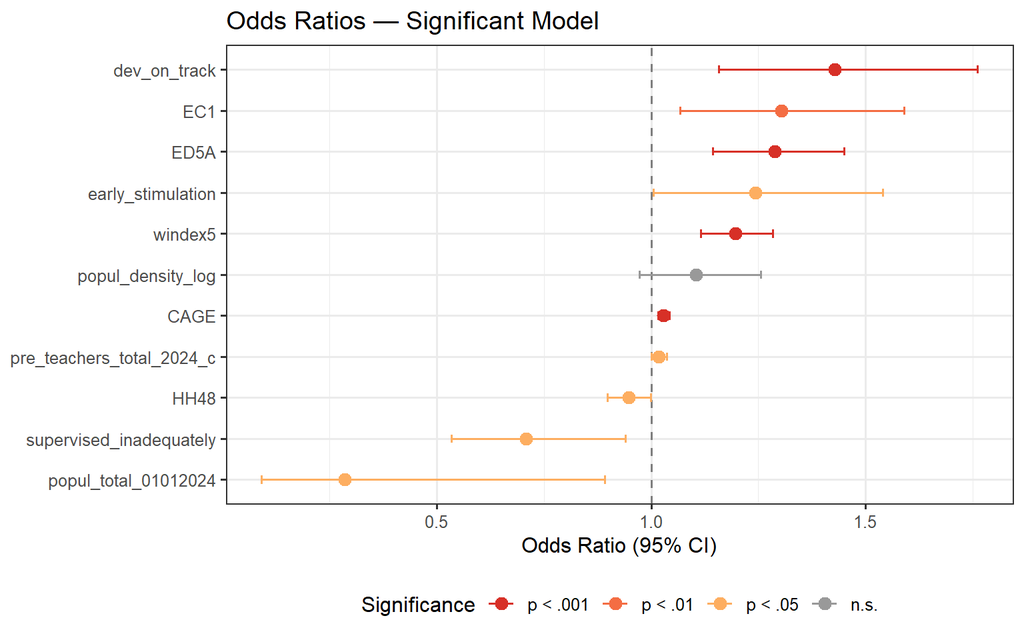

```r
# Plots
# Coefficient plot (OR forest plot) for model_sign

coef_df <- tidy(model_sign, effects = "fixed", conf.int = TRUE, exponentiate = TRUE) %>%
  filter(term != "(Intercept)") %>%
  mutate(
    sig = case_when(
      p.value < 0.001 ~ "p < .001",
      p.value < 0.01  ~ "p < .01",
      p.value < 0.05  ~ "p < .05",
      TRUE            ~ "n.s."
    ),
    sig = factor(sig, levels = c("p < .001", "p < .01", "p < .05", "n.s."))
  )

p_coef <- ggplot(coef_df, aes(x = estimate, y = reorder(term, estimate), color = sig)) +
  geom_vline(xintercept = 1, linetype = "dashed", color = "grey50") +
  geom_errorbar(aes(xmin = conf.low, xmax = conf.high), height = 0.2) +
  geom_point(size = 3) +
  scale_color_manual(
    values = c("p < .001" = "#d73027", "p < .01" = "#f46d43",
               "p < .05" = "#fdae61", "n.s." = "grey60")
  ) +
  labs(
    title    = "Odds Ratios — Significant Model",
    x        = "Odds Ratio (95% CI)",
    y        = NULL,
    color    = "Significance"
  ) +
  theme_bw(base_size = 12) +
  theme(legend.position = "bottom")

print(p_coef)
```

```
## `height` was translated to `width`.
```

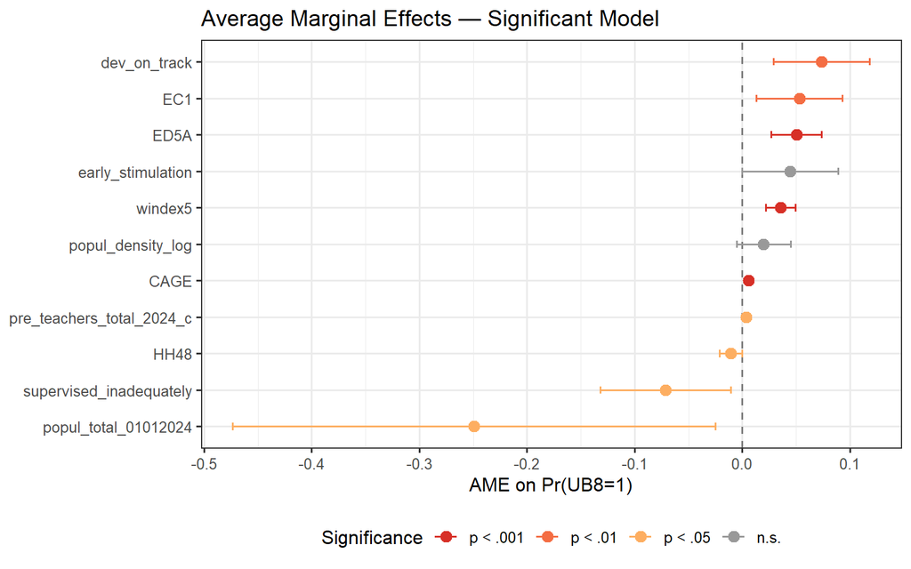

```r
# Marginal effects plot (AME)
ame_df <- as.data.frame(ame_model_sign) %>%
  filter(term != "(Intercept)") %>%
  mutate(
    sig = case_when(
      p.value < 0.001 ~ "p < .001",
      p.value < 0.01  ~ "p < .01",
      p.value < 0.05  ~ "p < .05",
      TRUE            ~ "n.s."
    ),
    sig = factor(sig, levels = c("p < .001", "p < .01", "p < .05", "n.s."))
  )

p_ame <- ggplot(ame_df, aes(x = estimate, y = reorder(term, estimate), color = sig)) +
  geom_vline(xintercept = 0, linetype = "dashed", color = "grey50") +
  geom_errorbarh(aes(xmin = conf.low, xmax = conf.high), height = 0.2) +
  geom_point(size = 3) +
  scale_color_manual(
    values = c("p < .001" = "#d73027", "p < .01" = "#f46d43",
               "p < .05" = "#fdae61", "n.s." = "grey60")
  ) +
  labs(
    title = "Average Marginal Effects — Significant Model",
    x     = "AME on Pr(UB8=1)",
    y     = NULL,
    color = "Significance"
  ) +
  theme_bw(base_size = 12) +
  theme(legend.position = "bottom")
print(p_ame)
```

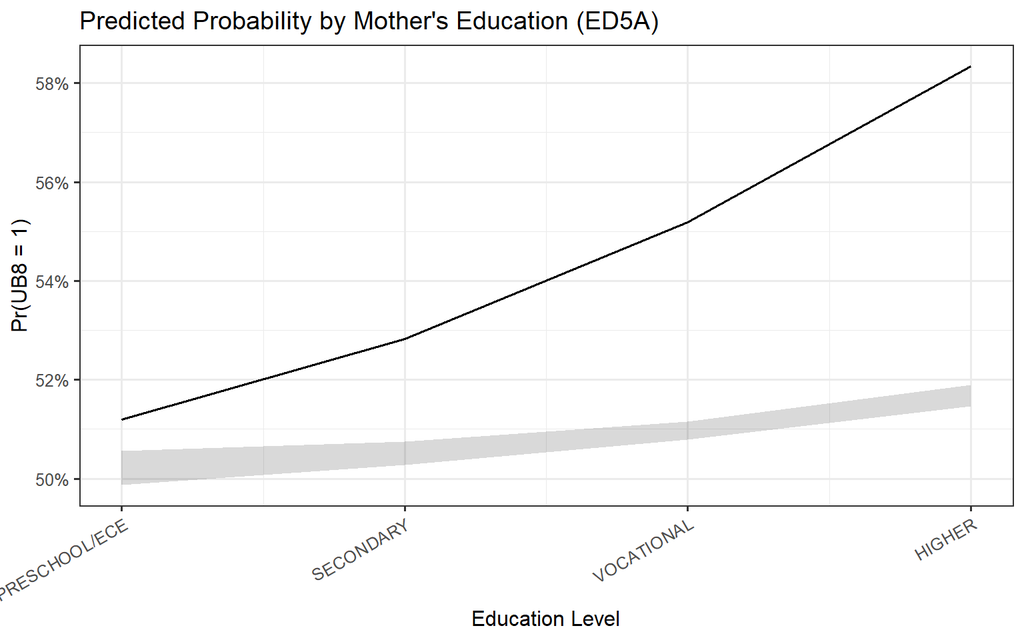

```r
#  Predicted probabilities for key predictors
pred_ed5a <- ggpredict(model_sign, terms = "ED5A [all]", bias_correction = TRUE)
p_ed5a <- plot(pred_ed5a) +
  labs(title = "Predicted Probability by Mother's Education (ED5A)",
       x = "Education Level", y = "Pr(UB8 = 1)") +
  theme_bw(base_size = 12)+
  theme(axis.text.x = element_text(angle = 30, hjust = 1))

pred_windex <- ggpredict(model_sign, terms = "windex5 [all]", bias_correction = TRUE)
p_windex <- plot(pred_windex) +
  labs(title = "Predicted Probability by Wealth Index",
       x = "Wealth Index (windex5)", y = "Pr(UB8 = 1)") +
  theme_bw(base_size = 12)

print(p_ed5a)
```

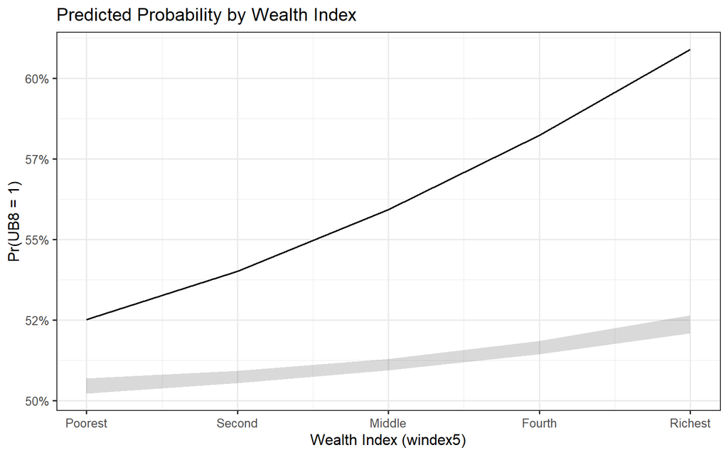

```r
print(p_windex)
```

```
## `height` was translated to `width`.
```

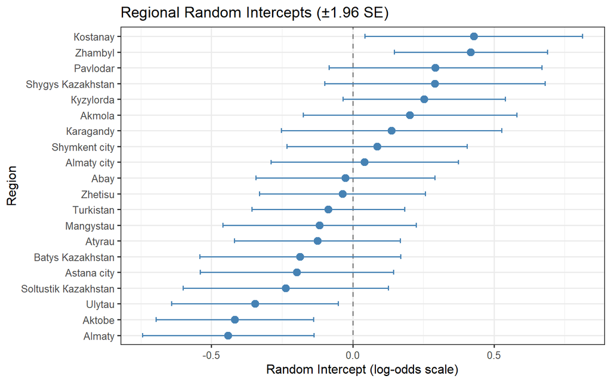

```r
#  4. Random effects (regional variation)
re_df <- ranef(model_sign, condVar = TRUE)$region %>%
  tibble::rownames_to_column("region") %>%
  rename(intercept = `(Intercept)`) %>%
  mutate(
    se = sqrt(attr(ranef(model_sign, condVar = TRUE)$region, "postVar")[1, 1, ]),
    lower = intercept - 1.96 * se,
    upper = intercept + 1.96 * se
  )

p_re <- ggplot(re_df, aes(x = intercept, y = reorder(region, intercept))) +
  geom_vline(xintercept = 0, linetype = "dashed", color = "grey50") +
  geom_errorbarh(aes(xmin = lower, xmax = upper), height = 0.3, color = "steelblue") +
  geom_point(size = 3, color = "steelblue") +
  labs(
    title = "Regional Random Intercepts (±1.96 SE)",
    x     = "Random Intercept (log-odds scale)",
    y     = "Region"
  ) +
  theme_bw(base_size = 12)

print(p_re)
```

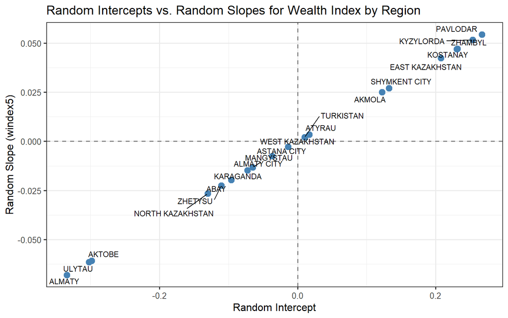

```r
#  5. Random slopes by region (model_extra: windex5 | region_mics)
re_slopes_df <- ranef(model_extra, condVar = TRUE)$region_mics %>%
  tibble::rownames_to_column("region") %>%
  rename(intercept = `(Intercept)`, slope_windex = windex5)

p_slopes <- ggplot(re_slopes_df, aes(x = intercept, y = slope_windex, label = region)) +
  geom_hline(yintercept = 0, linetype = "dashed", color = "grey50") +
  geom_vline(xintercept = 0, linetype = "dashed", color = "grey50") +
  geom_point(size = 3, color = "steelblue") +
  ggrepel::geom_text_repel(size = 3) +
  labs(
    title = "Random Intercepts vs. Random Slopes for Wealth Index by Region",
    x     = "Random Intercept",
    y     = "Random Slope (windex5)"
  ) +
  theme_bw(base_size = 12)

print(p_slopes)
```

```r
#  ICC and R² across models — summary bar chart
model_list <- list(
  "Null"        = model_null,
  "For Pooling" = model_for_pooling,
  "Full"        = model_full,
  "Significant" = model_sign,
  "Extra"       = model_extra
)

r2_df <- purrr::map_dfr(names(model_list), function(nm) {
  r2_vals <- r2(model_list[[nm]])
  icc_result <- tryCatch(
    performance::icc(model_list[[nm]])$ICC_adjusted,
    error = function(e) NA_real_
  )

  tibble::tibble(
    model        = nm,
    R2_marginal  = r2_vals$R2_marginal,
    R2_conditional = r2_vals$R2_conditional,
    ICC          = icc_result
  )
}) %>%
  tidyr::pivot_longer(-model, names_to = "metric", values_to = "value") %>%
  mutate(model = factor(model, levels = names(model_list)))
```

```
## boundary (singular) fit: see help('isSingular')
```

```
## Random effect variances not available. Returned R2 does not account for random effects.
```

```
## boundary (singular) fit: see help('isSingular')
```

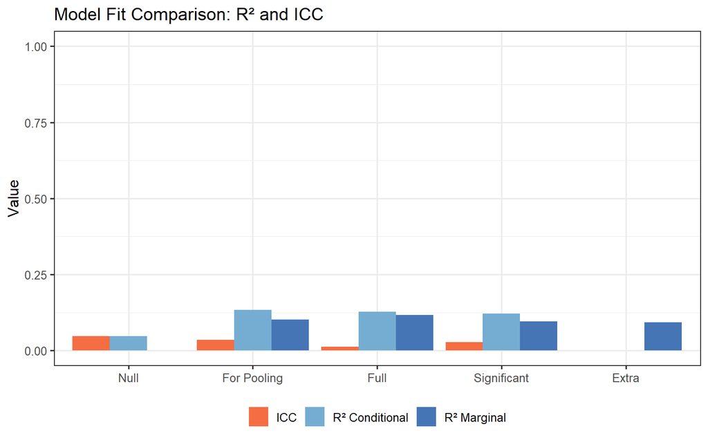

```r
p_r2 <- ggplot(r2_df, aes(x = model, y = value, fill = metric)) +
  geom_col(position = "dodge") +
  scale_fill_manual(
    values = c("R2_marginal" = "#4575b4", "R2_conditional" = "#74add1", "ICC" = "#f46d43"),
    labels = c("ICC", "R² Conditional", "R² Marginal")
  ) +
  labs(
    title = "Model Fit Comparison: R² and ICC",
    x     = NULL,
    y     = "Value",
    fill  = NULL
  ) +
  ylim(0, 1) +
  theme_bw(base_size = 12) +
  theme(legend.position = "bottom")

print(p_r2)
```

# Model predictive performance comparison

```r
# Splitting data

kaz_df <- kaz_df %>%
  mutate(strata_var = paste0(region_mics, "_", UB8))

train_idx <- createDataPartition(kaz_df$strata_var, p = 0.75, list = FALSE)
train_df  <- kaz_df[train_idx, ]
test_df   <- kaz_df[-train_idx, ]


# Refit all models on training data
# Swapping kaz_df to train_df in each model call
# Example:
model_null_train <- update(model_null, data = train_df)
model_pool_train <- update(model_for_pooling, data = train_df)
model_full_train <- update(model_full, data = train_df)
model_sign_train <- update(model_sign, data = train_df)
model_extra_train <- update(model_extra, data = train_df)
```

```
## boundary (singular) fit: see help('isSingular')
```

```r
# Predict test set
# allow.new.levels = TRUE handles regions in test not seen in train
predict_prob <- function(model, newdata) {
  predict(model, newdata = newdata, type = "response", allow.new.levels = TRUE)
}

probs <- list(
  Null = predict_prob(model_null_train, test_df),
  For_Pooling = predict_prob(model_pool_train, test_df),
  Full = predict_prob(model_full_train, test_df),
  Significant = predict_prob(model_sign_train, test_df),
  Extra = predict_prob(model_extra_train, test_df)
)


# Metrics

metrics_df <- purrr::map2_dfr(
  probs, names(probs),
  ~ compute_metrics(.x, as.numeric(as.character(test_df$UB8)), .y)
)
```

# Performance comparison table

```r
metrics_df %>%
  mutate(across(where(is.numeric), ~ round(.x, 3))) %>%
  gt::gt() %>%
  gt::tab_header(title = "Out-of-Sample Prediction Accuracy Comparison") %>%
  gt::fmt_number(columns = where(is.numeric), decimals = 3) %>%
  gt::cols_label(
    Model       = "Model",
    AUC         = "AUC",
    Accuracy    = "Accuracy",
    Sensitivity = "Sensitivity",
    Specificity = "Specificity",
    PPV         = "Precision (PPV)",
    F1          = "F1 Score",
    Brier       = "Brier Score",
    LogLoss     = "Log Loss"
  ) %>%
  gt::tab_style(
    style = gt::cell_fill(color = "#d4edda"),
    locations = gt::cells_body(
      rows = Accuracy == max(Accuracy)
    )
  )
```

Out-of-Sample Prediction Accuracy Comparison

| Model | AUC | Accuracy | Sensitivity | Specificity | Precision (PPV) | F1 Score | Brier Score | Log Loss |
| --- | --- | --- | --- | --- | --- | --- | --- | --- |
| Null | 0.624 | 0.692 | 0.969 | 0.092 | 0.698 | 0.811 | 0.207 | 0.604 |
| For_Pooling | 0.691 | 0.713 | 0.940 | 0.222 | 0.723 | 0.817 | 0.194 | 0.572 |
| Full | 0.683 | 0.715 | 0.931 | 0.246 | 0.728 | 0.817 | 0.195 | 0.575 |
| Significant | 0.683 | 0.707 | 0.929 | 0.227 | 0.722 | 0.813 | 0.195 | 0.576 |
| Extra | 0.687 | 0.705 | 0.935 | 0.208 | 0.719 | 0.813 | 0.195 | 0.575 |

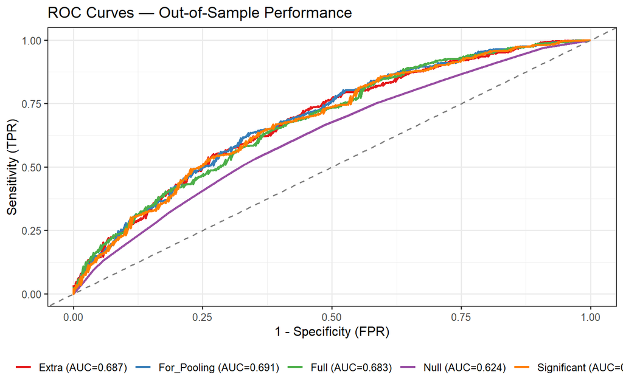

```r
# ROC curves plot (all models)
roc_list <- purrr::map2(probs, names(probs), function(p, nm) {
  roc_obj <- roc(as.numeric(as.character(test_df$UB8)), p, quiet = TRUE)
  data.frame(
    model       = paste0(nm, " (AUC=", round(auc(roc_obj), 3), ")"),
    sensitivity = roc_obj$sensitivities,
    specificity = roc_obj$specificities
  )
})

roc_df <- dplyr::bind_rows(roc_list)

p_roc <- ggplot(roc_df, aes(x = 1 - specificity, y = sensitivity, color = model)) +
  geom_line(linewidth = 0.9) +
  geom_abline(slope = 1, intercept = 0, linetype = "dashed", color = "grey50") +
  scale_color_brewer(palette = "Set1") +
  labs(
    title = "ROC Curves — Out-of-Sample Performance",
    x     = "1 - Specificity (FPR)",
    y     = "Sensitivity (TPR)",
    color = NULL
  ) +
  theme_bw(base_size = 12) +
  theme(legend.position = "bottom")

print(p_roc)
```

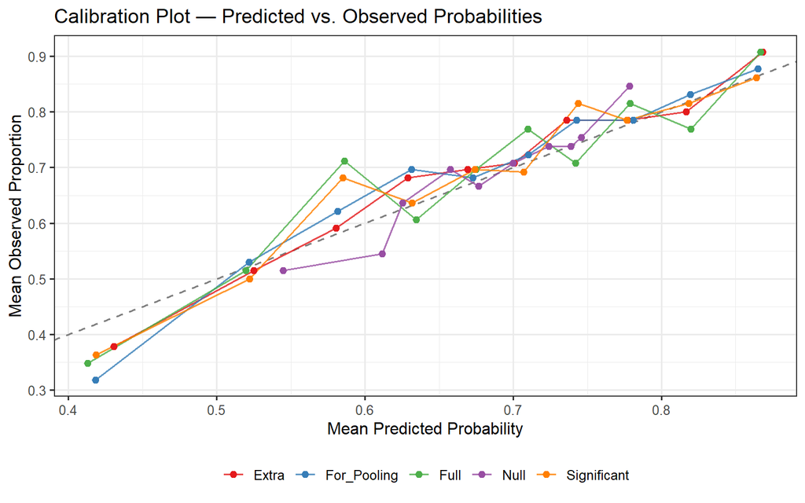

```r
# Calibration plot — predicted vs. observed probabilities
cal_df <- purrr::map2_dfr(probs, names(probs), function(p, nm) {
  data.frame(
    model    = nm,
    pred     = p,
    observed = as.numeric(as.character(test_df$UB8))
  )
})

# Bin predictions into deciles per model
cal_binned <- cal_df %>%
  dplyr::group_by(model) %>%
  dplyr::mutate(bin = ntile(pred, 10)) %>%
  dplyr::group_by(model, bin) %>%
  dplyr::summarise(
    mean_pred = mean(pred),
    mean_obs  = mean(observed),
    .groups   = "drop"
  )

p_cal <- ggplot(cal_binned, aes(x = mean_pred, y = mean_obs, color = model)) +
  geom_abline(slope = 1, intercept = 0, linetype = "dashed", color = "grey50") +
  geom_line(linewidth = 0.7, alpha = 0.8) +
  geom_point(size = 2) +
  scale_color_brewer(palette = "Set1") +
  labs(
    title = "Calibration Plot — Predicted vs. Observed Probabilities",
    x     = "Mean Predicted Probability",
    y     = "Mean Observed Proportion",
    color = NULL
  ) +
  theme_bw(base_size = 12) +
  theme(legend.position = "bottom")

print(p_cal)
```